# K-Means Clustering

Stacy Chandisingh, Leo Pena, Shaif Hossain

11/7/23

## Introduction: What is K-Means Clustering?

- An unsupervised machine learning technique
- K-means is a fixed number (k) of clusters in a dataset
- Used to draw conclusions about a dataset based on groups of similar variables
- Different ways to determine the ‘k’
- Used a Spotify dataset focused on attributes (examples: tempo and popularity) surrounding a music track to group similar features by clustering them together

## Methods: diving into the K-Means algorithm

- Assumptions
- WCSS
- Euclidean distance
- K-means assumes the clusters are symmetric, there can be asymmetrical clusters.
- The data is assumed to be independent.
- Properly scaled data is important for K-Means, it can lead to uneven clusters.
- There is a fixed number of clusters for K-Means.
- Descriptive statistics/histograms/correlation matrix to visualize the spread of the data.
- Preprocess and scale data for ease of comparability.
- Libraries used: tidyverse, cluster, and factoextra.
- The Euclidean distances are calculated to get the clustering distances measurement
- The distance data is visualized using the fviz_dist() function in R from the factoextra package.

WCSS per (Abdullah et al. 2021):

$$WCSS = \sum_{i=1}^{K}\sum_{j=1}^{ni}\left \| x_{ij} - c_{i} \right \|^2$$

- K is number of clusters.
- n<sub>i</sub> is number of data points in cluster i.
- C<sub>i</sub> is centroid.
- X<sub>ij</sub> is the *j*<sup>th</sup> data point in cluster I.

The WCSS can be used to measure how the data within a cluster are grouped. The variables that are used from the dataset are then scaled. Then, after they are scaled the next steps are:

Euclidean distance is calculated between each attribute, and the cluster center:
$$D_{euclidean}(x, Ki) = \sqrt{\sum_{i=1}^{n}((x_{i}) -(k)_{ij})^{2}}$$

Where:

- x is data point.
- k<sub>i</sub> is cluster center.
- n is number of attributes.
- x<sub>i</sub> is the *i*<sup>th</sup> attribute of the data point.
- K<sub>ij</sub> is the *j*<sup>th</sup> attribute of the centroid of cluster i.

## Analysis and Results: Data and Vizualisation

Data source: [Spotify data from Kaggle](https://www.kaggle.com/code/ryanholbrook/clustering-with-k-means/data?select=spotify.csv)

- Correlation Matrix
- Histogram

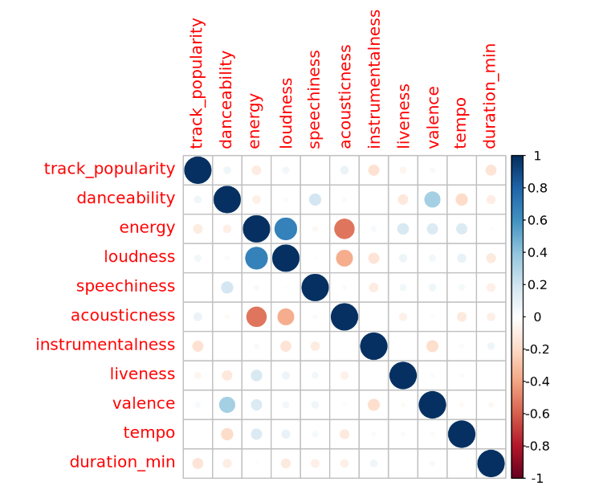

corrplot

In the correlation plot, the darker the blue the greater the correlation between the variables. The chart shows a positive correlation between energy and loudness and a negative correlation between acousticness and energy.

- Histogram of variables to assess distribution and normality

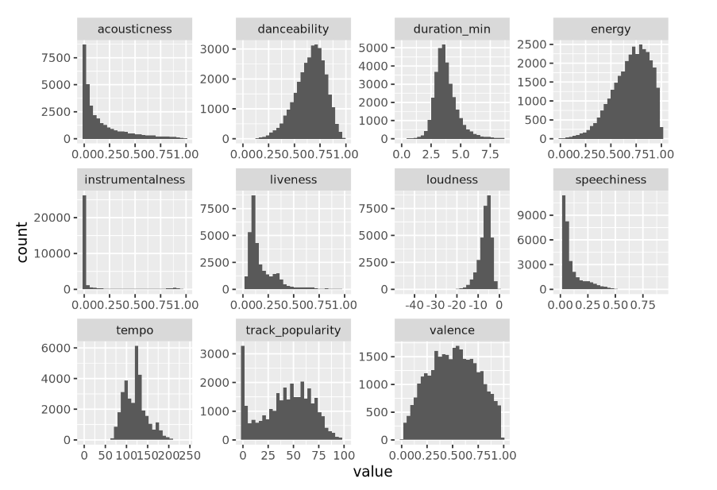

histogram

## Visualizing the data clusters

- The Elbow Curve
- Cluster plot
- The point at which the line starts to curve is where we get our “k” clusters. Hence the name “Elbow Curve”

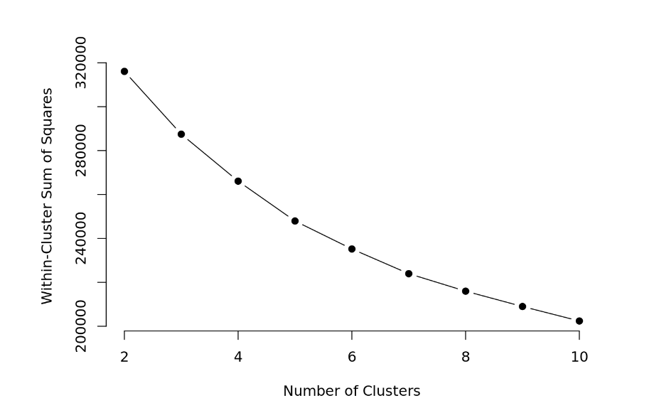

elbow

- Three distinct clusters are shown here.

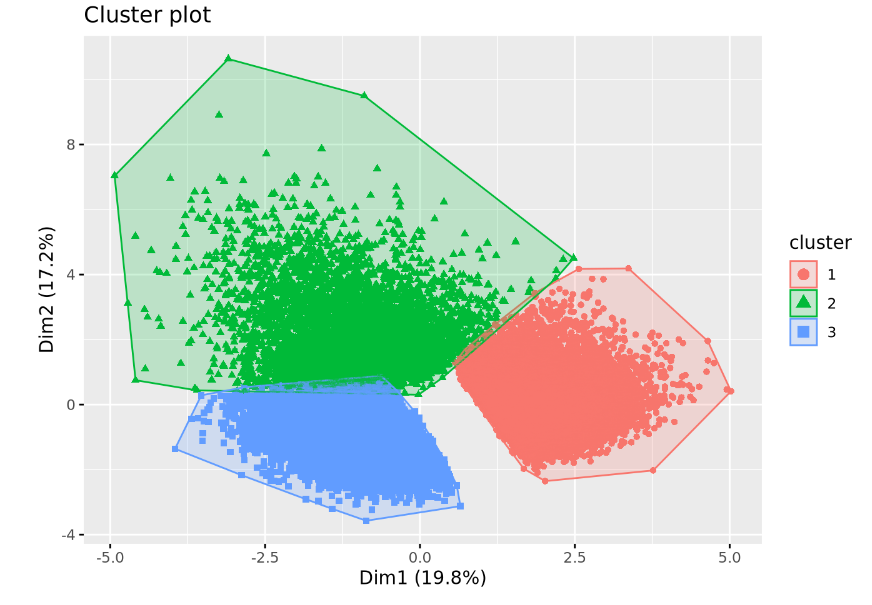

clusters

## What did we find?

Three clusters of similar music data

## Conclusions

- K-Means provides a simple yet insightful way to glean data insights.
- Unsupervised machine learning finds hidden data structures from an unlabeled dataset and its aim is to find the similarities within the data groups.
- Three cluster groups were found.
- We can offer song recommendations based on this analysis
- We recommend using other K-Means clustering methods to verify whether results are similar.

## References

Abdullah, Dahlan, S. Susilo, Ansari Saleh Ahmar, R. Rusli, and Rahmat Hidayat. 2021. “The Application of k-Means Clustering for Province Clustering in Indonesia of the Risk of the COVID-19 Pandemic Based on COVID-19 Data.” *Quality and Quantity* 56 (3): 1283–91. https://doi.org/10.1007/s11135-021-01176-w.